# Working with distributions in R

## Densities, Probabililites, Quantiles and random variables

For distributions R uses four standard functions that are helpful when doing statistical inference. Assume we are working with a Normal distribution, $N(\mu,\sigma^2)$. To caculate the density of the values in the vector, $x=(-1,0,1)$, for a $N(1,2)$ distribution, and store it in a vector $fx$, one do as follows:

```r
x <- c(-1, 0, 1)
mu     <- 1
sigma2 <- 2
fx <- dnorm(x, mean = mu, sd = sqrt(sigma2)) # sd is standard deviation
print(fx)
```

```
## [1] 0.1037769 0.2196956 0.2820948
```

To compute the probabilility that a random variable $X$, with distribution $N(5,1)$ ($X \sim N(5,1)$), is less then $10$, one do as follows:

```r
Px10 <- pnorm(10, mean = 5, sd = sqrt(1))
print(Px10)
```

```
## [1] 0.9999997
```

To compute the quantiles for a normal distribution, i.e the values $x_p$ such that $\mathbb{P}(X < x_p) =p$, one uses:

```r
Px05 <- qnorm(0.5, mean = 5, sd = sqrt(1))
print(Px05)
```

```
## [1] 5
```

Finally to generate $n=100$ random numbers with a Normal distribution (with mean ten and standard devation four) one do as follows:

```r
n <- 100
mu <- 10
sigma <- 4 #notice not sigma2
X <- rnorm(n = n, mean = mu, sd = sigma)
```

Thus for the normal distributin we have the four functions:

- `dnorm` for the densities
- `pnorm` for the probabilites
- `qnorm` for the quantilies
- `rnorm` for the random variables

This is not limited to just the normal distribution, the convention in r for an arbitrary distribution, NAME, is to * `dNAME` for the densities * `pNAME` for the probabilites * `qNAME` for the quantilies * `rNAME` for the random variables

So we can do exactly the same for the gamma distribution (which has two parameters $\alpha$ and $\beta$):

```r
alpha <- 2
beta <- 1
x <- seq(0, 1, length.out = 10)
fx   <- dgamma(x = x,   shape = alpha, scale = beta)
Px   <- pgamma(q = x,   shape = alpha, scale = beta)
x_90 <- qgamma(p = 0.9, shape = alpha, scale = beta)
X    <- rgamma(n = n,   shape = alpha, scale = beta)
```

Don’t forget that often the distribution can have several different parameterizations thus one need to make one uses the right one. And as always if you don’t know how the form use `help` and **read the contents**:

```r
help(dgamma)
```

## discrete distribution

A discrete distribution with a finite number of outcomes, can be represented by a vector:

```r
# does not need to be number
Xdomain <- c(1,4,5,6)
pX <- runif(n = 4)
pX <- pX / sum(pX) # the probabilility must integrate to one
```

Below we generate ten samples of X

```r
X <- sample(x       = Xdomain,
            size    = 10,
            replace = T,
            prob    = pX )
print(X)
```

```
##  [1] 4 4 5 1 4 4 4 6 6 1
```

One can visulaise the discrete density is to use barplot

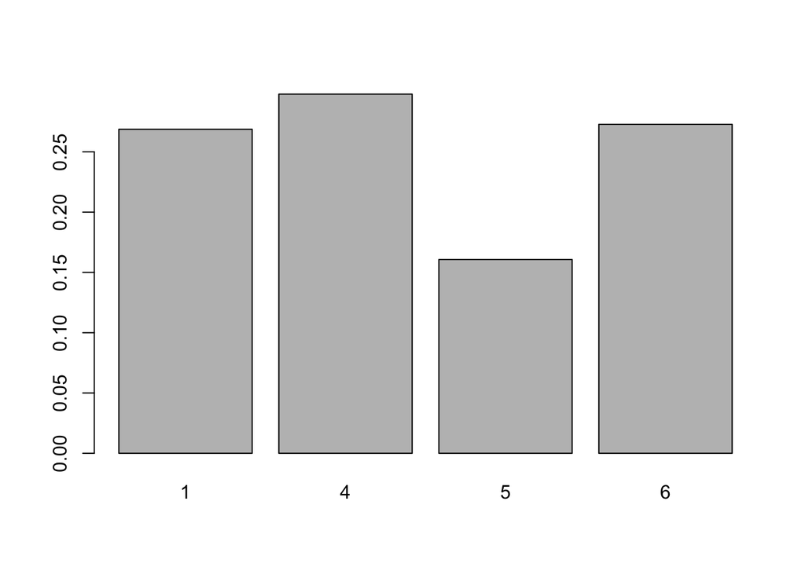

```r
names(pX) <- Xdomain
barplot(pX )
```

To visualise the emperical distribution:

```
## Table X:
```

```
##
## 1 4 5 6
## 2 5 1 2
```

```
## prop.table X:
```

```
##
##   1   4   5   6
## 0.2 0.5 0.1 0.2
```

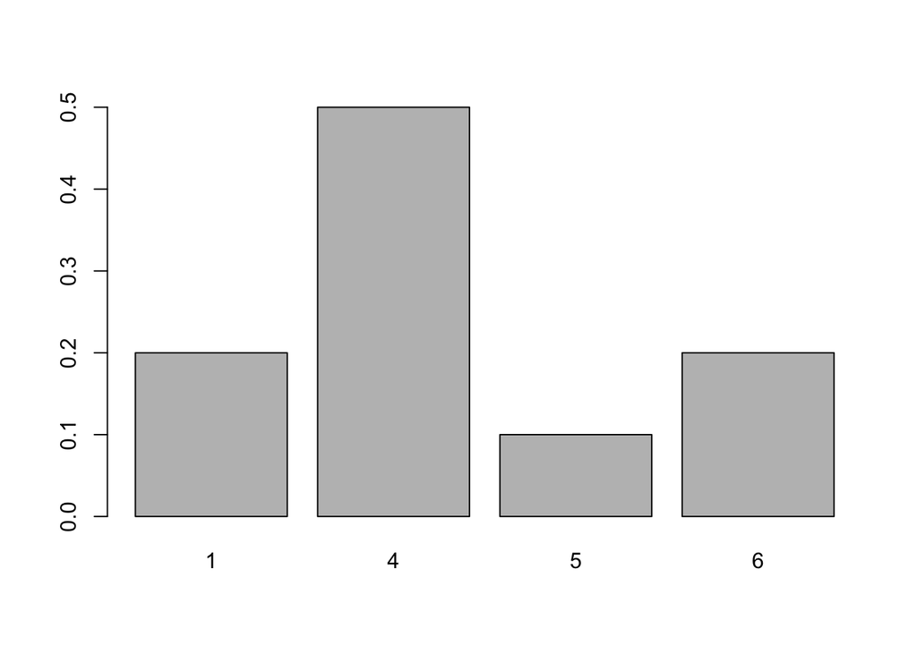

```r
Xsample_table <- table(factor(X,lev=Xdomain))  # table(X) does not work element can be missing X
cat('Table X:')
print(Xsample_table)

Xsample_freq_table <- prop.table(Xsample_table)
cat('prop.table X:')
print(Xsample_freq_table)
barplot(Xsample_freq_table)
```

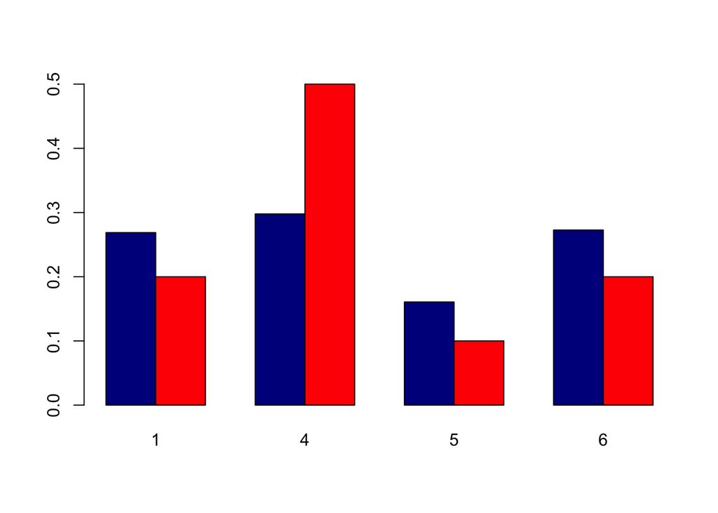

```r
multiTable <- as.table(rbind(pX, prop.table(table(X))))
colnames(multiTable) <- Xdomain
barplot(multiTable, beside = T, col=c("darkblue","red"))
```

## two dimensional discrete distribution

A two dimensional distribution can be defined by a matrix

```r
# does not need to be number
Xdomain <- c(1, 4, 5, 6)
Ydomain <- c('A', 'B', 'C')
# rows are
PXY <- matrix(runif(length(Xdomain) * length(Ydomain)),
              nrow = length(Xdomain),
              ncol  = length(Ydomain))
rownames(PXY) <- Xdomain
colnames(PXY) <- Ydomain
PXY <- PXY / sum(PXY)
print(PXY)
```

```
##            A           B          C
## 1 0.15367260 0.083756220 0.17218248
## 4 0.01729522 0.044521556 0.01472568
## 5 0.07904242 0.045119159 0.14831949
## 6 0.10387488 0.001767555 0.13572274
```

```r
# the maringal density for X
PX <- rowSums(PXY)
print(PX)
```

```
##          1          4          5          6
## 0.40961131 0.07654246 0.27248106 0.24136517
```

```r
# the maringal density for X
PY <- colSums(PXY)
print(PY)
```

```
##         A         B         C
## 0.3538851 0.1751645 0.4709504
```

Sampling joint distribution $X,Y$:

```r
n_samples <- 10
GRID <- expand.grid(X=Xdomain, Y=Ydomain)
#sampling the index
index <- sample(x = 1:length(PXY), size=n_samples, replace=TRUE, prob= c(PXY))
XY <- GRID[index,]
rownames(XY) <- 1:n_samples
cat('sample X,Y:')
print(XY)
```

```
## sample X,Y:
```

```
##    X Y
## 1  5 C
## 2  1 B
## 3  1 A
## 4  5 C
## 5  1 B
## 6  6 C
## 7  1 B
## 8  5 C
## 9  6 C
## 10 1 A
```

Sampling the conditional distributions:

```r
PX_YA <- PXY[,1]/sum(PXY[,1]) #conditional distribution P(X,Y='A')/P(Y='A')
X <- sample(x = Xdomain, size=10, replace=TRUE, prob= PX_YA) # samples from the conditional distribution
print(X)
```

```
##  [1] 1 1 5 1 1 1 6 6 6 5
```